# Coursera: rmarkdown; Reproducible Research

# Code to describe and show a strategy for imputing missing data

To calculate the total number of missing values in the dataset, we used the below command.

```r
missing <- sum(is.na(activity$steps))
missing
```

```
## [1] 2304
```

We see that 2304 observations are missing value.

Now, we use mean values to replace them with missing values.

```r
ImputedData <- activity
for (i in 1:nrow(ImputedData)) {
    if (is.na(ImputedData$steps)[i]) {
        # Find the index value for when the interval matches the average
        ndx <- which(ImputedData$interval[i] ==
        activity$interval)
        # Assign the value to replace the NA
        ImputedData$steps[i] <- group_mean[ndx,]$Mean
    }
}
```

# Histogram of the total number of steps taken each day after missing values are imputedS

Again, we used ggplot function to make a histogram of the total number of steps taken each day.

```r
group_sum <- na.omit(ImputedData) %>%
    group_by(date) %>%
    summarise_at(vars(steps),
                 list(Sum_Frequency = sum))
group_sum
```

```
## # A tibble: 61 × 2
##    date       Sum_Frequency
##    <date>             <dbl>
##  1 2012-10-01         1981.
##  2 2012-10-02          126
##  3 2012-10-03        11352
##  4 2012-10-04        12116
##  5 2012-10-05        13294
##  6 2012-10-06        15420
##  7 2012-10-07        11015
##  8 2012-10-08         1981.
##  9 2012-10-09        12811
## 10 2012-10-10         9900
## # ℹ 51 more rows
```

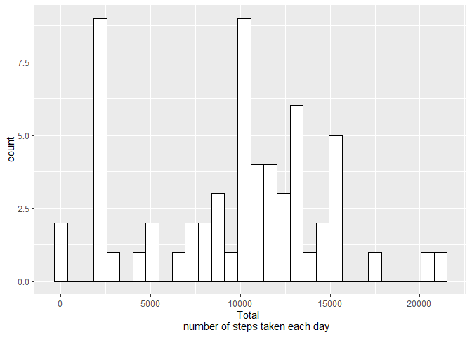

```r
ggplot(group_sum, aes(x=Sum_Frequency)) +
    geom_histogram(color="black", fill="white") + xlab("Total
    number of steps taken each day")
```

Now, we Calculate and report the mean and median total number of steps taken per day. We see that the NA values are replaced with mean and median values which could give us a idea about missing values.

```r
group_mean <- na.omit(ImputedData) %>%
    group_by(date) %>%
    summarise_at(vars(steps),
                 list(Mean = mean))
group_mean
```

```
## # A tibble: 61 × 2
##    date         Mean
##    <date>      <dbl>
##  1 2012-10-01 37.4
##  2 2012-10-02  0.438
##  3 2012-10-03 39.4
##  4 2012-10-04 42.1
##  5 2012-10-05 46.2
##  6 2012-10-06 53.5
##  7 2012-10-07 38.2
##  8 2012-10-08 37.4
##  9 2012-10-09 44.5
## 10 2012-10-10 34.4
## # ℹ 51 more rows
```

```r
group_median <- na.omit(ImputedData) %>%
    group_by(date) %>%
    summarise_at(vars(steps),
                 list(Median = median))
group_median
```

```
## # A tibble: 61 × 2
##    date       Median
##    <date>      <dbl>
##  1 2012-10-01   37.4
##  2 2012-10-02    0
##  3 2012-10-03    0
##  4 2012-10-04    0
##  5 2012-10-05    0
##  6 2012-10-06    0
##  7 2012-10-07    0
##  8 2012-10-08   37.4
##  9 2012-10-09    0
## 10 2012-10-10    0
## # ℹ 51 more rows
```

We used the **weekdays** function to extract the days of the weeks and the create the new variable to define weekdays and weekends.

```r
ImputedData$day <- weekdays(ImputedData$date)
ImputedData$daytype <- "weekday"
ImputedData$daytype[ImputedData$day %in% c("Saturday", "Sunday")] <- "weekend"
dayaverage <- na.omit(ImputedData) %>%
    group_by(daytype, interval) %>%
    summarize(AverageSteps=mean(steps))
```

Now, we can make a panel plot containing a time series plot of the 5-minute interval (x-axis) and the average number of steps taken, averaged across all weekday days or weekend days (y-axis).

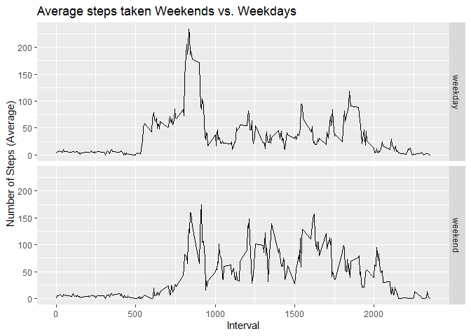

```r
qplot(interval, AverageSteps, data=dayaverage,
      type="l",geom="line",xlab="Interval",
      ylab="Number of Steps (Average)",
      main="Average steps taken Weekends vs. Weekdays",
      facets =daytype ~ .)
```